# HW10: Significance Testing & Effect Size

You previously calculated the mean, margin of error and confidence interval for monthly car thefts in Prince George’s County. Your editor now wants to know: it *looks* like car thefts are decreasing lately, but is that change real, and how big is it? In this assignment, you’ll use significance testing and effect size to answer those questions. Load the tidyverse and the data to get started.

### Task 1: Load the tidyverse and the data

```r
# Read the data
car_thefts <- read_csv("https://raw.githubusercontent.com/dwillis/jour405/refs/heads/main/data/car_thefts_month.csv") |>
  arrange(month)  # Sort by date
```

### Task 2: Split the data and test for significance (4 points)

We’ll split the monthly data into two halves, and then ask whether there’s a statistically significant difference between these periods. To do that, we’ll use a t-test with our alpha at 0.05. First, fill in the hypotheses, then replace the REPLACE_ME values in the code.

**Null Hypothesis:** There’s no difference inbetween the averages of car thefts between the two halves of the data.

**Alternative Hypothesis:** The second half has a lower average number of thefts than the first half meaning they have decreased over time.

```r
# Find the halfway point and add a column placing each month in the first or second halves

midpoint <- ceiling(nrow(car_thefts) / 2)
car_thefts <- car_thefts |>
  mutate(period = if_else(row_number() <= midpoint, "First Half", "Second Half"))

# Perform t-test comparing the two time periods
t_test_periods <- t.test(total ~ period, data = car_thefts)

# Display results
t_test_periods
```

```
##
##  Welch Two Sample t-test
##
## data:  total by period
## t = 5.0666, df = 28.835, p-value = 2.14e-05
## alternative hypothesis: true difference in means between group First Half and group Second Half is not equal to 0
## 95 percent confidence interval:
##   75.57222 177.92778
## sample estimates:
##  mean in group First Half mean in group Second Half
##                  438.9375                  312.1875
```

**Answer this question:** What is the p-value? Is it less than 0.05? Can we reject the null hypothesis? What does this tell your editor?

The p-value is less than 0.05 showing a statistically significant difference between the two halves. Because it’s below 0.05 we can reject the null. This tells the editor that the decline in thefts is not likely to be because of random chance and is probably a real change over time.

### Task 3: Visualize the comparison (4 points)

Let’s see the two periods side by side with their confidence intervals. Replace the REPLACE_ME values.

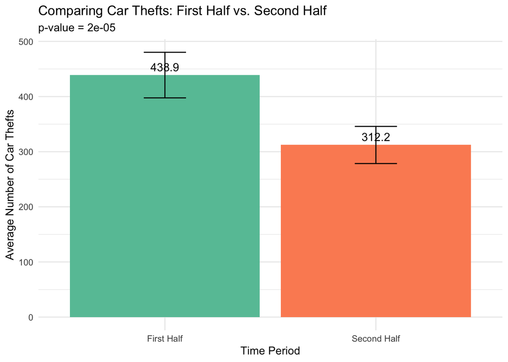

```r
# Summarize by period
period_summary <- car_thefts |>
  group_by(period) |>
  summarize(
    mean_thefts = mean(total),
    sd_thefts = sd(total),
    months = n(),
    se_thefts = sd_thefts / sqrt(months),
    margin_error = qt(0.975, df = months - 1) * se_thefts,
    ci_lower = mean_thefts - margin_error,
    ci_upper = mean_thefts + margin_error
  )

period_summary |>
ggplot(aes(x = period, y = mean_thefts, fill = period)) +
  geom_col() +
  geom_errorbar(aes(ymin = ci_lower, ymax = ci_upper), width = 0.2) +
  geom_text(aes(label = round(mean_thefts, 1)), vjust = -0.5, size = 4) +
  labs(
    title = "Comparing Car Thefts: First Half vs. Second Half",
    subtitle = paste0("p-value = ", round(t_test_periods$p.value, 5)),
    x = "Time Period",
    y = "Average Number of Car Thefts"
  ) +
  scale_fill_manual(values = c("First Half" = "#66c2a5", "Second Half" = "#fc8d62")) +
  theme_minimal() +
  theme(legend.position = "none")
```

**Answer this question:** Look at the error bars (confidence intervals) on the chart. Do they overlap? What does that tell you about whether the difference between the two periods is real?

The confidence intervals for the two periods do not overlap at all. This shows the difference in average car thefts between the two halves is real and not random.

### Task 4: Calculate the effect size (5 points)

We’ve established that the decline is statistically significant. But how large is it? Let’s calculate Cohen’s d to measure the effect size. For a two-sample comparison, we use the pooled standard deviation:

**Pooled SD** = sqrt(((n1 - 1) × sd1² + (n2 - 1) × sd2²) / (n1 + n2 - 2))

**Cohen’s d** = (mean1 - mean2) / pooled SD

Replace the REPLACE_ME values. You’ll need to pull the values from `period_summary`.

```r
# Extract the values from period_summary
first_half_stats <- period_summary |> filter(period == "First Half")
second_half_stats <- period_summary |> filter(period == "Second Half")

# Calculate pooled standard deviation
pooled_sd <- sqrt(
  ((first_half_stats$months - 1) * first_half_stats$sd_thefts^2 +
   (second_half_stats$months - 1) * second_half_stats$sd_thefts^2) /
  (first_half_stats$months + second_half_stats$months - 2)
)

# Calculate Cohen's d
cohens_d <- (first_half_stats$mean_thefts - second_half_stats$mean_thefts) / pooled_sd

# Interpret it
effect_label <- case_when(
  abs(cohens_d) < 0.2 ~ "Negligible",
  abs(cohens_d) < 0.5 ~ "Small",
  abs(cohens_d) < 0.8 ~ "Medium",
  TRUE ~ "Large"
)

tibble(
  `First half mean` = round(first_half_stats$mean_thefts, 1),
  `Second half mean` = round(second_half_stats$mean_thefts, 1),
  `Difference` = round(first_half_stats$mean_thefts - second_half_stats$mean_thefts, 1),
  `Cohen's d` = round(cohens_d, 3),
  `Interpretation` = effect_label
)
```

```
## # A tibble: 1 × 5
##   `First half mean` `Second half mean` Difference `Cohen's d` Interpretation
##               <dbl>              <dbl>      <dbl>       <dbl> <chr>
## 1              439.               312.       127.        1.79 Large
```

**Answer this question:** How would you describe this effect size? Compare it to the effect sizes we calculated in class (the response times activity had a small effect, the housing prices activity had a medium effect). What does a large effect size mean for the story you’d write about car thefts?

The effect size is large showing the substantial difference between the two halves. The avg number of thefts dropped by about 127 incidents per month which is huge. Comparing it to the class examples this result is much stronger- noticeable decline and significant change in real-world terms. For the story this supports a clear conclusion that thefts have decreased.

### Task 5: Putting it all together (7 points)

You now have three pieces of evidence: the confidence intervals from last week, the significance test from this assignment, and the effect size.

1. In Part 1, your editor asked “just tell me if car thefts are going up or down”. Now you have significance testing. Write 2-3 sentences telling your editor the answer, using all three pieces of evidence (CI, p-value, and effect size).

Car thefts in PG County are decreasing and the data strongly supports this. The CI’s for the two periods we looked at do not overlap, the p-value is far below 0.05 and the effect size is large. All of these tests on the data indicated that the decline is statistically significant and has sound data to back it up.

2. Write a headline and a 2-3 sentence lede for a story about car thefts in Prince George’s County. Unlike the response times story from class (where the effect was small and the headline needed to be cautious), this is a case where the data strongly supports a clear conclusion. Your writing should reflect that — but still note the limitations (correlation vs. causation, what else might explain the decline).

Car Thefts Drop Sharply in Prince George’s County

Car thefts in PG County have declined significantly in recent months, with statistical testing on theft data showing a substantial decrease and a strong likelihood this is not down to random fluctuation. While data confirms the decline, it does not identify the cause– factors such as policing changes or seasonal trends may help explain the drop.

When you are finished, save your work, switch to GitHub Desktop, then add, commit and push your changes to GitHub and submit the URL of the notebook in ELMS.